# Econometría

v.2026.11.24

PDF

## ¿Cómo representamos diferencias entre grupos?

## ¿Existen diferencias salariales entre hombres y mujeres?

Consideremos los salarios por hora de 1,289 personas entrevistadas en los Estados Unidos (*Current Population Survey, marzo de 1995*).

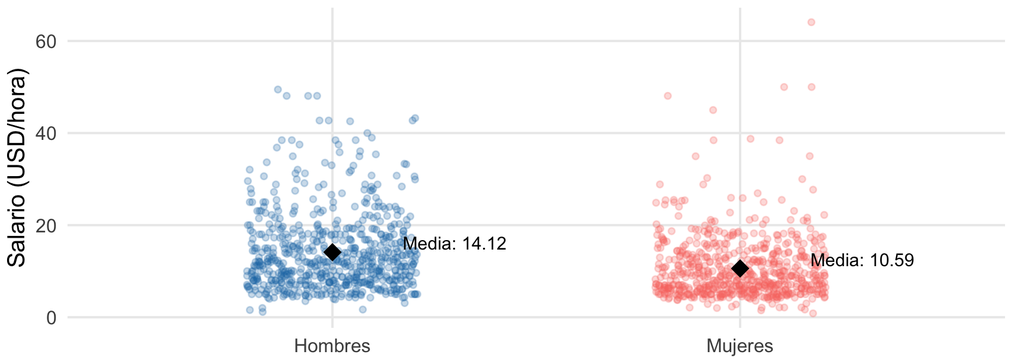

> ¿Podemos representar las diferencias salariales entre ambos grupos mediante un modelo de regresión?

## ¿Cómo incorporamos una característica cualitativa?

Hasta ahora hemos utilizado *variables cuantitativas* para explicar el comportamiento de la variable dependiente. Sin embargo, también podemos estar interesados en las *características cualitativas* de los individuos:

- Definimos las **variables dummy** (también llamadas *variables binarias*, *dicotómicas* o *indicadoras*).
- Las variables dummy solo pueden tomar dos valores. Por ejemplo:

\[ D_i=\begin{cases} 1 & \text{si la persona es mujer},\\ 0 & \text{si la persona es hombre}. \end{cases} \]

El grupo para el cual \(D_i=0\) se conoce como **grupo de referencia**.

## Una regresión para dos grupos

Una variable dummy se incorpora al modelo como cualquier otra variable. Por ejemplo, si la variable dependiente es el salario y tenemos una variable dummy de género, tenemos:

\[ y_i=\beta_1+\beta_2D_i+u_i. \]

Nota que, si se cumplen los supuestos de Gauss-Markov sobre el error, entonces:

\[ E(y_i)=\begin{cases} \beta_1 & \text{para los hombres},\\ \beta_1+\beta_2 & \text{para las mujeres}. \end{cases} \]

En otras palabras, \(\beta_1\) representa el salario esperado de los hombres, mientras que \(\beta_2\) representa la diferencia entre los salarios esperados de las mujeres y de los hombres.

## MCO y la diferencia de medias

Ejercicio

Muestra que, si estimamos el modelo por MCO:

\[ b_1=\overline{y}_H\qquad\text{y}\qquad b_2=\overline{y}_M-\overline{y}_H, \]

donde \(\overline{y}_H\) y \(\overline{y}_M\) representan los salarios promedio de hombres y mujeres, respectivamente. En nuestro ejemplo:

\[ \widehat{y}_i=14.1189-3.5252D_i. \]

*¡MCO reproduce exactamente las medias muestrales de ambos grupos!*

## ¿Importa qué grupo utilizamos como referencia?

Ejercicio

¿Qué pasa si usamos a las mujeres como grupo de referencia? Esto es:

\[ D_i^*=\begin{cases} 1 & \text{si la persona es hombre},\\ 0 & \text{si la persona es mujer}. \end{cases} \]

Muestra que, al utilizar esta nueva variable, la regresión estimada puede escribirse como:

\[ \widehat{y}_i=(b_1+b_2)-b_2D_i^*. \]

¿Cómo interpretamos ahora los coeficientes? ¿Qué sucede con los valores ajustados, los residuales y la \(R^2\)?

## ¿Es estadísticamente significativa la diferencia? (1/2)

En nuestra muestra, las mujeres ganan en promedio 3.53 dólares por hora *menos* que los hombres. Pero, ¿tenemos evidencia estadística de una diferencia poblacional? Para saberlo, probamos:

\[ H_0:\beta_2=0\qquad\text{vs.}\qquad H_1:\beta_2\neq0. \]

En nuestro ejemplo, el estadístico de la prueba es: \(t=-8.22\).

> Existe evidencia estadística de una diferencia salarial. Pero, ¿es suficiente comparar los promedios?

## ¿Es estadísticamente significativa la diferencia? (2/2)

Ejercicio

Utilizando las propiedades de MCO y suponiendo que se satisfacen los supuestos de Gauss-Markov sobre el error, muestra que:

\[ \operatorname{Var}(b_2)=\sigma^2\left(\frac{1}{n_H}+\frac{1}{n_M}\right), \]

donde \(n_H\) y \(n_M\) representan el número de hombres y mujeres en la muestra, respectivamente.

## Más de una característica

## ¿Es suficiente comparar los promedios?

¿Qué pasa si los grupos difieren en más de una característica?

En nuestro ejemplo, es posible que hombres y mujeres tengan distintos niveles de educación y experiencia laboral. Estas características también pueden incorporarse al modelo:

\[ y_i=\beta_1+\beta_2educ_i+\beta_3exper_i+\delta D_i+u_i. \]

> ¿Cómo interpretamos ahora el coeficiente asociado con la variable dummy?

## ¿Qué estamos comparando?

En este modelo:

- Si \(D_i=0\) (hombres):

\[ E(y_i)=\beta_1+\beta_2educ_i+\beta_3exper_i. \]

- Si \(D_i=1\) (mujeres):

\[ E(y_i)=(\beta_1+\delta)+\beta_2educ_i+\beta_3exper_i. \]

Entonces, \(\delta\) representa la *diferencia entre los salarios esperados de dos personas con los mismos niveles de educación y experiencia, pero distinto género*.

## ¿Qué estamos suponiendo?

Veamos cómo se relaciona el salario con la educación para hombres y mujeres, manteniendo constante la experiencia potencial en 18 años.

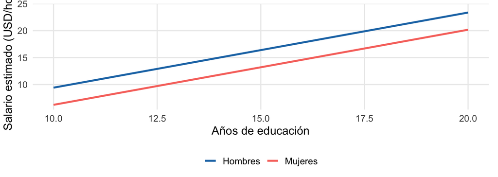

El modelo permite diferentes interceptos, pero *supone que la relación entre educación y salario es la misma para ambos grupos* (es decir, tenemos dos rectas paralelas).

## ¿Qué ocurre en nuestro ejemplo?

En nuestro ejemplo, la estimación por MCO resulta en:

| Variable | Modelo 1 | Modelo 2 |
| --- | --- | --- |
| Constante | 14.1189 | -7.6530 |
| Educación | — | 1.3937 |
| Experiencia potencial | — | 0.1747 |
| Mujer | -3.5252 | -3.1864 |
| No blanca | — | — |
| Sindicalización | — | — |
| Observaciones | 1289 | 1289 |

## ¿Podemos hablar de discriminación?

Ejercicio

En nuestro ejemplo tenemos que \(\operatorname{se}(b_\delta)=0.3646\). Usando este resultado, evalúa la hipótesis:

\[ H_0:\delta=0\qquad\text{vs.}\qquad H_1:\delta\neq0. \]

¿Podrían existir otras características relevantes que no hemos incorporado en nuestro modelo?

> ¿Una diferencia salarial estadísticamente significativa constituye necesariamente evidencia de discriminación?

## ¿Y si utilizamos un modelo log-lin?

Ejercicio*

Consideremos ahora el modelo:

\[ \ln(y_i)=\beta_1+\beta_2educ_i+\beta_3exper_i+\delta D_i+u_i. \]

Muestra que, cuando \(D_i\) cambia de \(0\) a \(1\), el cambio porcentual en \(y_i\) es: \(100(e^\delta-1)\). En nuestro ejemplo, este es: \(-23.20\). ¿Qué significa?

## ¿Qué ocurre cuando existen más de dos grupos?

## ¿Cómo representamos más de dos grupos?

Supongamos que ahora queremos estudiar las diferencias salariales entre los siguientes grupos de nuestra muestra:

- Hombres blancos.
- Mujeres blancas.
- Hombres no blancos.
- Mujeres no blancas.

Como cada persona pertenece a uno y solo uno de estos grupos, podemos definir una variable dummy para cada uno.

> Pero, ¿necesitamos realmente cuatro variables dummy?

## ¿Cuántas variables dummy necesitamos?

Ejercicio*

Supongamos que definimos una variable dummy para cada grupo:

| Grupo | \(D_{1i}\) | \(D_{2i}\) | \(D_{3i}\) | \(D_{4i}\) |
| --- | --- | --- | --- | --- |
| Hombres blancos | 1 | 0 | 0 | 0 |
| Mujeres blancas | 0 | 1 | 0 | 0 |
| Hombres no blancos | 0 | 0 | 1 | 0 |
| Mujeres no blancas | 0 | 0 | 0 | 1 |

Explica por qué no podemos incorporar los cuatro indicadores en un modelo de regresión que contiene una constante. Este problema se conoce como la **trampa de las variables dummy**.

> En general, si tenemos \(G\) categorías mutuamente excluyentes y exhaustivas, utilizamos \(G-1\) indicadores cuando el modelo contiene una constante.

## Una regresión para cuatro grupos

Ejercicio

Utilicemos a los hombres blancos como grupo de referencia e incorporemos los demás indicadores en nuestro modelo:

\[ \begin{aligned} y_i={}&\beta_1+\beta_2educ_i+\beta_3exper_i\\ &+\delta_2D_{2i}+\delta_3D_{3i}+\delta_4D_{4i}+u_i. \end{aligned} \]

- Obtén el salario esperado para cada uno de los cuatro grupos. ¿Cómo interpretamos los parámetros \(\delta_2\), \(\delta_3\) y \(\delta_4\)?
- Demuestra que podemos representar el mismo modelo eliminando la constante e incorporando los cuatro indicadores. ¿Cómo interpretamos ahora sus coeficientes?

## ¿Qué diferencias encontramos en nuestro ejemplo?

Si, además de las variables propuestas, incorporamos una variable dummy sobre sindicalización (\(1\) si sindicalizado, \(0\) si no), obtenemos:

| Variable | Coeficiente | Error estándar |
| --- | --- | --- |
| Constante | -7.0887 | 1.0195 |
| Educación | 1.3701 | 0.0659 |
| Experiencia potencial | 0.1659 | 0.0161 |
| Sindicalización | 1.1150 | 0.5064 |
| Mujeres blancas | -3.2401 | 0.3953 |
| Hombres no blancos | -2.1585 | 0.7484 |
| Mujeres no blancas | -4.3033 | 0.6868 |

## ¿Cómo comparamos los demás grupos?

Ejercicio

¿Cómo podemos comparar los salarios de las mujeres blancas con los de las mujeres no blancas?

- ¿Qué hipótesis debemos establecer para evaluar si existen diferencias salariales entre mujeres blancas y mujeres no blancas?
- ¿Qué estadístico debemos utilizar?
- ¿Qué hipótesis debemos establecer para evaluar si existen diferencias salariales entre los diferentes grupos?

## ¿Es igual la relación entre educación y salarios para todos?

## ¿Es igual la relación entre educación y salario?

Hasta ahora hemos permitido que hombres y mujeres tengan distintos interceptos, pero hemos supuesto que las pendientes son iguales para ambos grupos. ¿Qué pasa si queremos relajar este supuesto?

Considera la siguiente especificación (que incluye una *variable interactiva*):

\[ \begin{aligned} y_i={}&\beta_1+\beta_2educ_i+\beta_3exper_i\\ &+\delta D_i+\lambda(D_i\times educ_i)+u_i. \end{aligned} \]

> ¿Cómo interpretamos ahora los parámetros \(\beta_2\) y \(\lambda\)?

## ¿Qué hemos cambiado en nuestro modelo?

Usando esta nueva especificación, podemos ver cómo es la relación entre el salario y la educación para hombres y mujeres, manteniendo constante la experiencia potencial en 18 años.

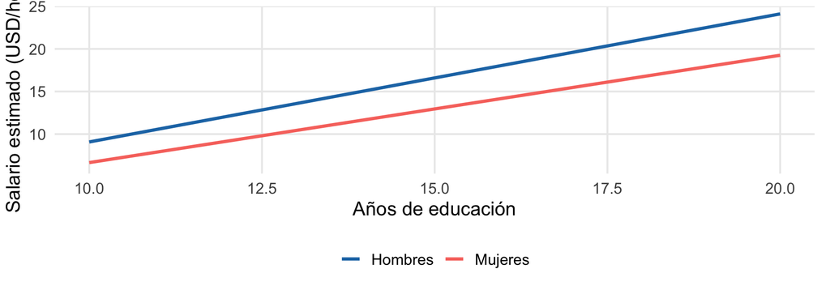

*¡Ahora las rectas no necesariamente son paralelas!* El parámetro \(\lambda\) representa la diferencia entre las pendientes de educación de ambos grupos.

## ¿Son diferentes las pendientes?

Ejercicio

Estimemos nuestro modelo utilizando los datos salariales.

| Variable | Coeficiente | Error estándar |
| --- | --- | --- |
| Constante | -9.0740 | 1.2600 |
| Educación | 1.5034 | 0.0881 |
| Experiencia potencial | 0.1731 | 0.0159 |
| Mujer | 0.0079 | 1.7466 |
| Mujer × Educación | -0.2432 | 0.1301 |

- ¿Tenemos evidencia estadística de que las pendientes para la educación de hombres y mujeres son diferentes al 5%?
- Construye un intervalo de confianza al 95% para la pendiente de educación de las mujeres.

## ¿Cómo interpretamos ahora el coeficiente de la dummy?

Ejercicio

Observa que, en nuestra última regresión, el coeficiente asociado con la variable `female` es prácticamente igual a cero:

\[ b_\delta=0.0079. \]

¿Significa esto que ya no encontramos diferencias salariales entre hombres y mujeres?

## ¿Podemos elegir otro punto de referencia?

Ejercicio

Supongamos que nos interesa estudiar la diferencia salarial entre hombres y mujeres con 12 años de educación. Para esto, definimos: \(educ_i^*=educ_i-12\). En este caso, el modelo se vuelve:

\[ \begin{aligned} y_i={}&\beta_1^*+\beta_2educ_i^*+\beta_3exper_i\\ &+\delta^*D_i+\lambda(D_i\times educ_i^*)+u_i. \end{aligned} \]

Demuestra que:

\[ \beta_1^*=\beta_1+12\beta_2\qquad\text{y}\qquad\delta^*=\delta+12\lambda. \]

¿Qué representan ahora \(\beta_1^*\) y \(\delta^*\)? ¿Qué sucede con los valores ajustados y los residuales?

## ¿Cómo cambia la diferencia salarial con la educación?

Podemos estimar la diferencia salarial entre hombres y mujeres como: \(\widehat{\Delta}(educ_0)=b_\delta+b_\lambda educ_0\), donde \(educ_0\) cualquier nivel educativo:

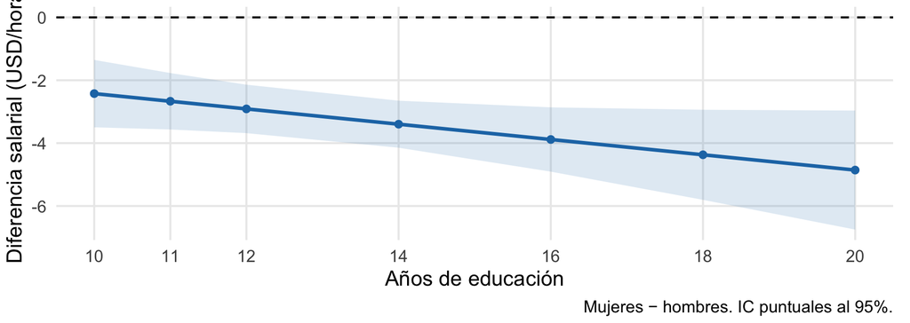

¿Podemos afirmar que la brecha salarial aumenta en magnitud con el nivel educativo?

## ¿Depende una diferencia entre grupos de otra característica cualitativa?

## ¿Es igual la diferencia salarial para todos los grupos?

Supongamos que queremos estudiar si la diferencia salarial entre hombres y mujeres depende del grupo racial al que pertenecen. El modelo es:

\[ y_i=\beta_1+\beta_2educ_i+\beta_3exper_i+\delta D_i+\gamma R_i+u_i, \]

donde \(D_i=1\) si la persona es mujer y cero en otro caso y \(R_i=1\) si la persona es no blanca y cero en otro caso.

*¿Cómo obtendrías la diferencia salarial esperada entre mujeres y hombres cuando \(R_i=0\) y cuando \(R_i=1\).*

## Una interacción entre variables dummy

Para permitir que la diferencia salarial entre hombres y mujeres sea distinta en ambos grupos raciales, podemos incorporar una interacción:

\[ \begin{aligned} y_i={}&\beta_1+\beta_2educ_i+\beta_3exper_i\\ &+\delta D_i+\gamma R_i+\lambda(D_iR_i)+u_i. \end{aligned} \]

¿Cómo interpretamos ahora los parámetros \(\delta\), \(\gamma\) y \(\lambda\)?

## ¿Qué encontramos en nuestro ejemplo?

Ejercicio

Estimemos nuestro modelo incorporando también la sindicalización como variable de control.

| Variable | Coeficiente | Error estándar |
| --- | --- | --- |
| Constante | -7.0887 | 1.0195 |
| Educación | 1.3701 | 0.0659 |
| Experiencia potencial | 0.1659 | 0.0161 |
| Sindicalización | 1.1150 | 0.5064 |
| Mujer | -3.2401 | 0.3953 |
| No blanca | -2.1585 | 0.7484 |
| Mujer × No blanca | 1.0954 | 1.0129 |

- ¿Cómo se calcula la diferencia salarial entre mujeres y hombres dentro de cada grupo racial.
- ¿Qué nos indica el signo del coeficiente de interacción?

## ¿Son estadísticamente diferentes las brechas?

En nuestro ejemplo encontramos diferencias salariales entre hombres y mujeres en ambos grupos raciales. Pero, ¿tenemos evidencia estadística de que estas diferencias son distintas entre sí?

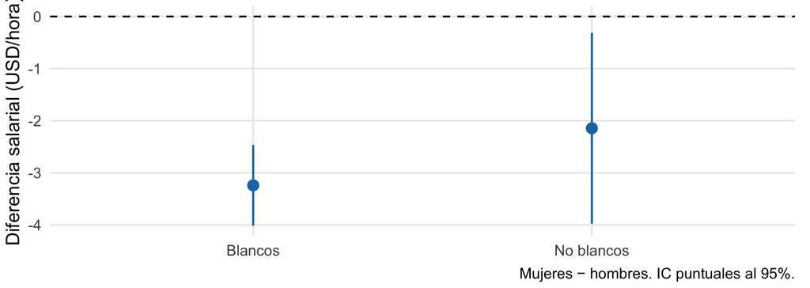

Para responder, evaluamos:

\[ H_0:\lambda=0\qquad\text{vs.}\qquad H_1:\lambda\neq0. \]

## ¿No habíamos estimado ya este modelo?

Ejercicio

Antes construimos un modelo con tres variables dummy para representar cuatro grupos, utilizando a los hombres blancos como referencia:

\[ y_i=\beta_1+\delta_2D_{2i}+\delta_3D_{3i}+\delta_4D_{4i}+u_i. \]

Pero ahora construimos el modelo:

\[ y_i=\beta_1+\delta D_i+\gamma R_i+\lambda(D_iR_i)+u_i. \]

Demuestra que ambas especificaciones son equivalentes. ¿Qué relación existe entre sus parámetros? ¿Qué sucede con los valores ajustados y los residuales?

## ¿Son iguales las funciones de regresión?

Ejercicio

Hasta ahora hemos permitido que hombres y mujeres tengan diferentes interceptos y pendientes de educación. Podemos extender esta idea y permitir que *todos los coeficientes* sean diferentes entre ambos grupos:

\[ \begin{aligned} y_i={}&\beta_1+\beta_2educ_i+\beta_3exper_i\\ &+\delta D_i+\lambda(D_i educ_i)+\theta(D_i exper_i)+u_i. \end{aligned} \]

- Obtén las funciones salariales para hombres y mujeres.
- ¿Cómo probarías la hipótesis de que los coeficientes de hombres y mujeres son iguales?

## Resumen

## ¿Qué hemos aprendido?

En este capítulo aprendimos a incorporar características cualitativas en nuestros modelos de regresión.

Las variables dummy nos permiten:

- Estimar diferencias entre grupos.
- Comparar grupos con características similares según nuestro modelo.
- Representar diferentes interceptos y pendientes.
- Evaluar hipótesis sobre las diferencias entre funciones de regresión.

*La pregunta económica que queremos responder determina cómo debemos especificar nuestro modelo.*

> Encontrar diferencias entre grupos no significa necesariamente que hayamos identificado sus causas.

## ¿Qué sigue?

En los últimos capítulos hemos aprendido a especificar modelos que permiten representar relaciones económicas cada vez más flexibles. Sin embargo, ¿qué sucede si nuestro modelo está mal especificado?

- ¿Si omitimos una variable relevante?
- ¿Si incorporamos variables innecesarias?
- ¿Si elegimos una forma funcional inadecuada?

En el siguiente capítulo estudiaremos algunos de estos **problemas de especificación**.

> ¿Cómo saber si hemos elegido un modelo adecuado?